# MSB.102: Biostatistics and Experimental Design: Final Exam, Course Sections 1-2

Adam Clark & Kristina Sefc

2024-29-11

Analyse the following datasets using generalised least squares (GLS) or mixed effects modelling (ME). Then use the results of your analyses to answer the following questions. Record your answers and corresponding R commands on the answer sheet (with informative comments!) and submit them over the Moodle site before the end of class. Please make your answers *short* - just a few words and lines of code per question is enough.

You may use notes, internet searches, AI, etc. to help you with the assignments - however, you must answer the questions yourself (i.e. no working together with other students).

## Question 1: Fishery Count Data (14 points total)

Imagine that you are a fishery biologist trying to identify the impact of two different classes of toxins on fish population sizes. You are given the following dataset on fish populations from your colleague:

```r
fdat = read.csv("d1_fishery.csv")
head(fdat)
```

```
##   fish_count  toxin_1   toxin_2
## 1         30 0.000000 0.5251420
## 2         27 0.000000 0.0000000
## 3         20 3.802897 0.0000000
## 4         20 3.745484 0.0000000
## 5          0 6.145938 0.8885874
## 6         19 3.565566 0.0000000
```

### Question 1.1: 2 point

Fit a simple “intercept only” model predicting average fish population size for the full dataset (i.e. using the formula ‘fish_count ~ 1’).

What distributional family did you use for your model (hint: think “fish”, but in French…)?

### Question 1.2: 1 point

What does your fitted model tell us about the average fish population size? Hint: recall that you will need to account for the link function while interpreting your regression.

### Question 1.3: 3 points

Fit models testing:

1. the effect of each toxin on fish population size
2. the multivariate effect of both toxins on fish population size
3. the interactive effects of both toxins of fish population size

and record the R commands that you used to fit the models on your answer sheet.

### Question 1.4: 2 points

Which of these models fits the data best? Justify your answer using some kind of quantitative test.

### Question 1.5: 3 points

Use your best fitting model to predict the expected fish population sizes for three hypothetical sites:

1. a “control” site, where the concentration of both toxins is 0
2. “site A”, where the concentration of toxin_1 = 1.5, but the concentration of toxin_2 = 0
3. “site B”, where the concentration of toxin_1 = 0.5 and the concentration of toxin_2 = 1.2

Hint: remember the link function for the distributional family that you chose while fitting your models.

### Question 1.6: 3 points

Biologically speaking, what does the best fitting model tell us about the effect of these two toxins on fish population sizes?

## Question 2: Germination Rates and Temperature (9 points total)

As part of a plant germination experiment, you are trying to discover the effect of temperature on germination success. You collect the following data comparing germination rates and pot soil temperatures:

[output not shown]

```r
gdat = read.csv("d2_germination.csv")
head(gdat)
```

```
##         temp germination
## 1   2.268598           0
## 2  38.039162           1
## 3 -14.147704           0
## 4 -11.088682           0
## 5  15.755158           1
## 6 -10.049382           0
```

### Question 2.1: 2 point

Fit a simple “intercept only” model predicting average germination success across the whole dataset (i.e. using the formula ‘germination ~ 1’).

What distributional family did you use for your model?

### Question 2.2: 1 point

What does your fitted model tell us about average rates of germination success? Hint: recall that you will need to account for the link function while interpreting your regression. Consider the two following functions to help you do so:

```r
logit = function(p) {log(p/(1-p))}
ilogit = function(x) {1/(1+exp(-x))}
```

### Question 2.3: 3 points

Fit a model testing the impacts of soil temperature on germination rates. What does the fitted model tell you about the relationship between temperature and germination success?

### Question 2.4: 3 points

Use your fitted model to predict the relationship between germination success and soil temperature across a range of temperatures from -30 to 40 degrees. Add a line showing this relationship to the following figure:

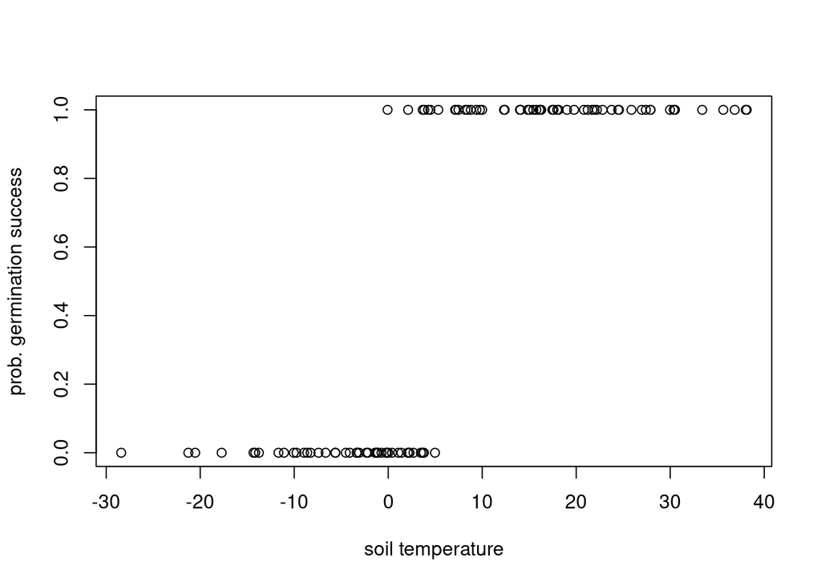

```r
plot(germination~temp, gdat, xlab = "soil temperature", ylab = "prob. germination success")
```

How does germination success change as you go from low to high temperatures? Is there a critical value at which germination success changes drastically?

## Question 3: Plant Biodiversity Experiment (12 points total)

You have been asked by your supervisor to tests for relationships between biodiversity and productivity in a grassland plant experiment. Each of 30 plots have been planted with mixtures of 1, 2, 4, 8, or 16 grassland plant species, and the corresponding dry aboveground biomass has been measured at the end of the growing season for the past 3 years:

```r
bdat = read.csv("d3_biodiversity.csv")
head(bdat)
```

```
##   plot_id year biodiversity productivity
## 1       1    1            1     13.94024
## 2       2    1            8     25.04064
## 3       3    1            2     23.87935
## 4       4    1            2     13.89339
## 5       5    1            4     25.68341
## 6       6    1            2     26.12128
```

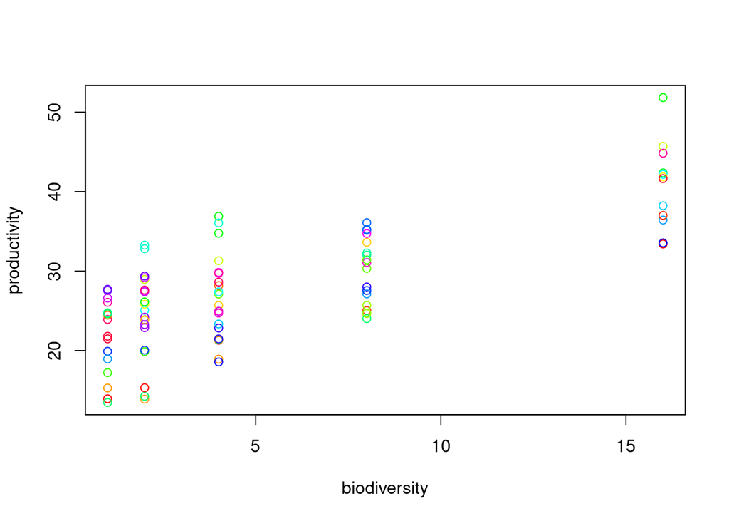

```r
plot(productivity ~ biodiversity, bdat, col = rainbow(30)[bdat$plot_id])
```

Note: each plot is shown in a different color.

### Question 3.1: 2 points

Fit a simple linear model to the data using the following command:

```r
require(nlme)
  mod3.0 = gls(productivity ~ biodiversity, data = bdat)
```

What are the slope and intercept for this model? Are they significant? What do these terms tell us about the relationship between biomass and productivity in this experiment?

### Question 3.2: 3 points

Now, update the model described above to include a random intercept term grouped by plot_id, using the commands in the nlme package.

What is the resulting plot-level variability (can be expressed as variance or standard deviation) for the regression? How does it compare to the residual (unexplained) variability?

### Question 3.3: 3 points

Compare the two models via ANOVA. Which model provides a better fit for the data? Hint: remember that you might need to refit the models with a different algorithm before comparing them.

### Question 3.4: 2 points

Make a histogram showing the plot-level random effects for the regression in Question 3.2 (you only need to upload the code for doing so, not the image).

### Question 3.5: 2 points

What kind of statistical distribution do these random effects follow? What are the mean and standard deviation of the distribution?

## Question 4: Mouse Growth Data (11 points total)

You are testing the impact of a “super food” on mouse growth. You have a population of 20 mice to test the effect of the super food - you feed 10 of these mice a normal diet, and 10 of the mice receive the super food. You then measure the weight of each mouse daily for the next two weeks. During the experiment, you notice that mouse growth follows a roughly linear pattern, but the resulting growth curves show that the rate differs substantially across individual mice regardless of their diet:

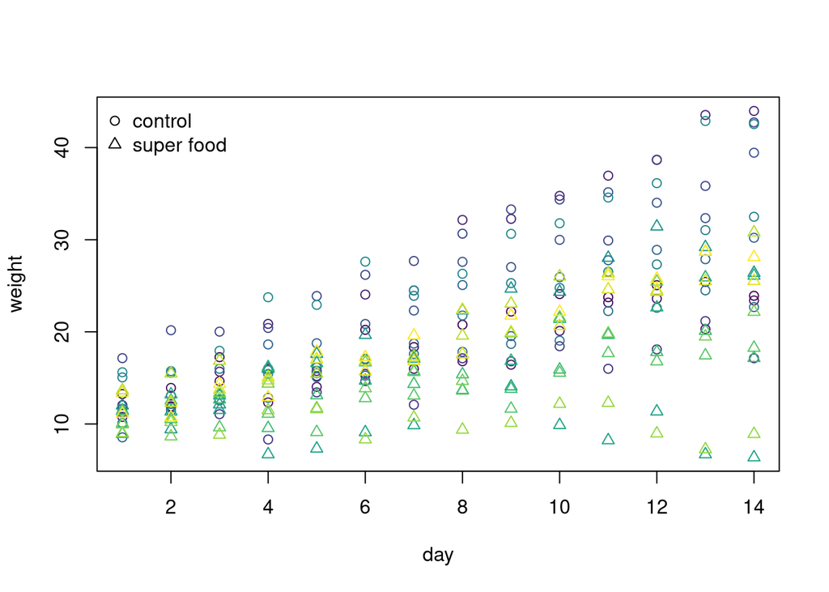

```r
mdat = read.csv("d4_mouse.csv")
head(mdat)
```

```
##   mouse_id day  food   weight
## 1        1   1 super 13.25267
## 2        2   1 super 10.76620
## 3        3   1 super 12.03984
## 4        4   1 super 11.26142
## 5        5   1 super 17.14548
## 6        6   1 super 11.63167
```

where each color shows the growth pattern for a different mouse.

### Question 4.1: 2 points

Fit a linear model of the form:

```r
require(nlme)
mod4.0 = gls(weight ~ day*food, data = mdat)
```

What is the effect of the super food on initial mouse size (at t = 0)? What is the effect of the super food on mouse growth (hint: look at the “day:” variable)? Are either effect significant?

### Question 4.2: 3 points

Now, update the model described above to include a random intercept term grouped by mouse_id, using the commands in the nlme package.

What is the resulting mouse-level variability (can be expressed as variance or standard deviation) for the regression? How does it compare to the residual (unexplained) variability?

### Question 4.3: 3 points

Next, update the model described above to include a random slope term grouped by mouse_id.

What is the resulting mouse-level variability (can be expressed as variance or standard deviation) for the slope term in the regression? How does it compare to the variability of the intercept and the residual (unexplained) variability?

### Question 4.4: 3 points

Compare the three models using AIC. Which is the best fitting model for this dataset? How do you know?

## Bonus Question: (+4 points total)

Consider the following dataset:

```r
data(iris)
head(iris)
```

```
##   Sepal.Length Sepal.Width Petal.Length Petal.Width Species
## 1          5.1         3.5          1.4         0.2  setosa
## 2          4.9         3.0          1.4         0.2  setosa
## 3          4.7         3.2          1.3         0.2  setosa
## 4          4.6         3.1          1.5         0.2  setosa
## 5          5.0         3.6          1.4         0.2  setosa
## 6          5.4         3.9          1.7         0.4  setosa
```

Build a model predicting Sepal.Length as a function of some combination of the other variables in the dataset. You can choose what kind of model to use (i.e. lm, glm, lme, etc.). What does your fitted model tell us about the relationship between Sepal.Length and the other variables you choose to include in your model?